# R Notebook

## Versão mais elegante usando o pacote ggplot2

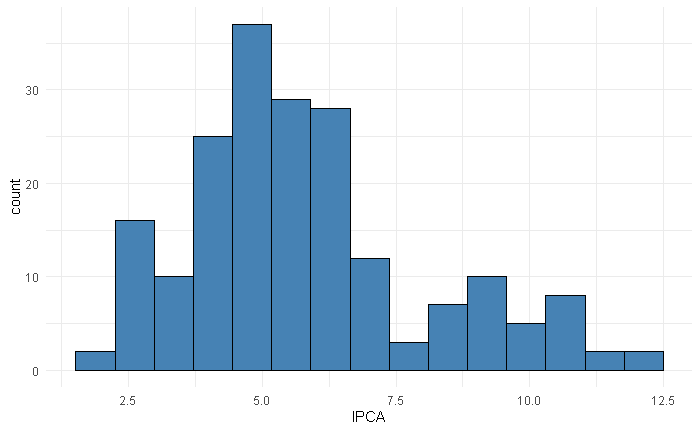

```r
dados <- data.frame(IPCA=as.numeric(serie))

ggplot(dados,
       aes(IPCA))+
  geom_histogram(
    bins=15,
    fill="steelblue",
    color="black"
  )+
  theme_minimal()
```

## Densidade (Complementando o histograma.)

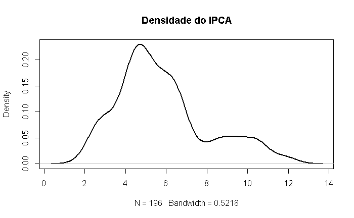

```r
plot(
  density(serie),
  lwd=2,
  main="Densidade do IPCA"
)
```

## Boxplot (Muito útil para identificar outliers.)

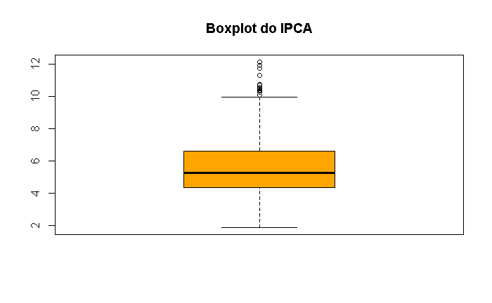

```r
boxplot(
  serie,
  col="orange",
  main="Boxplot do IPCA"
)
```

### Versão ggplot

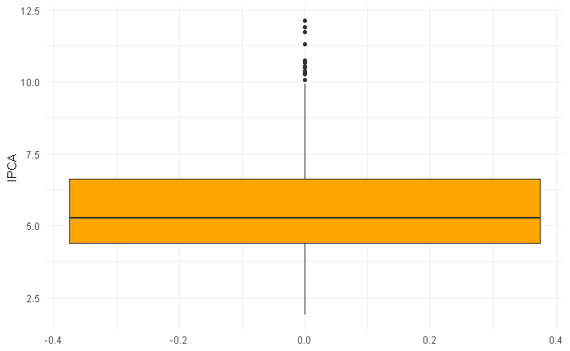

```r
ggplot(
  dados,
  aes(y=IPCA)
)+
  geom_boxplot(
    fill="orange"
  )+
  theme_minimal()
```

## Identificando Outliers. Se aparecerem valores extremos: Nem sempre devemos removê-los. Em séries econômicas: Crises, Pandemia, Choques de oferta, Mudanças cambiais podem gerar observações extremas que fazem parte do fenômeno econômico.

```r
boxplot.stats(serie)$out
```

```
 [1] 10.48 10.67 10.71 10.36 10.25 10.67 10.74 10.06 10.38 10.54 11.30 12.13 11.73 11.89 10.07
```

## Observando a assimetria dos dados. 0 → simétrica, > 0 → cauda à direita < 0 → cauda à esquerda

```r
install.packages("moments")
library(moments)

skewness(serie)
```

```
[1] 0.8103131
```

# Observando a curtose dos dados, se aparenta com distribuição normal. Curtose > 3 → caudas pesadas, Curtose ≈ 3 → normal, Curtose < 3 → distribuição achatada

```r
kurtosis(serie)
```

```
[1] 3.116649
```

### Agora vamos para uma das partes mais importantes da análise de séries temporais: a decomposição da série. O objetivo é separar a série observada em componentes para entender melhor sua dinâmica.

## Decomposição da Série Temporal

# Visualizando a Série Novamente. Antes da decomposição:

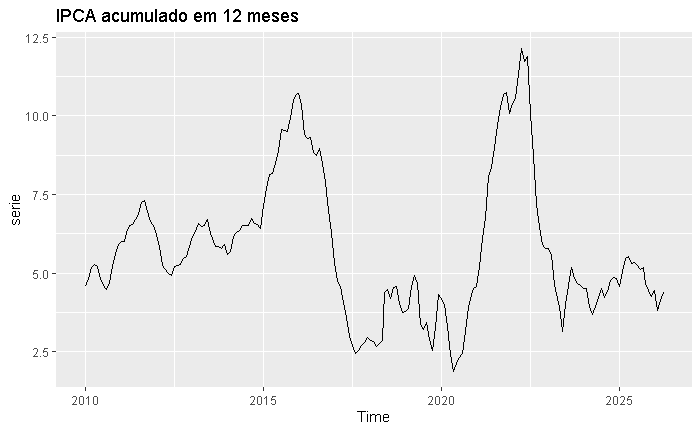

# Decomposição Clássica. Método tradicional.

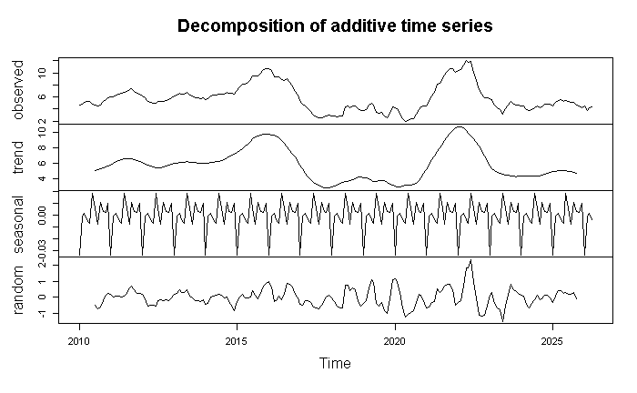

```r
decomp <- decompose(serie)

plot(decomp)
```

## Decomposição STL. É o procedimento mais utilizado atualmente. Se analisa mais as tendencias que existem nas seríes

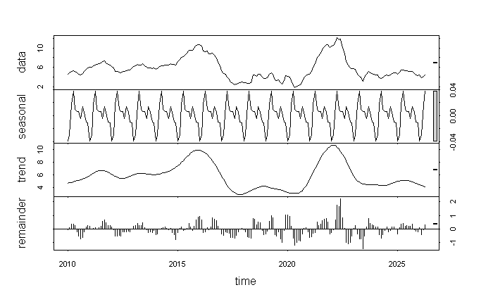

```r
decomp_stl <- stl(
  serie,
  s.window = "periodic"
)

plot(decomp_stl)
```

## Testes Formais

# Teste de Tendência. Vamos verificar se existe tendência determinística na série.

## Se o resultado for estatisticamente significante então tem tendencia

##Criamos uma variável tempo. Decisão Se: p-value < 0.05. Concluímos:Existe tendência estatisticamente significativa. ## A série é não estacionaria

```r
tempo <- 1:length(serie)

modelo_tend <- lm(
  serie ~ tempo
)

summary(modelo_tend)
```

```
Call:
lm(formula = serie ~ tempo)

Residuals:
    Min      1Q  Median      3Q     Max
-3.7546 -1.3583 -0.4667  0.5587  6.6253

Coefficients:
             Estimate Std. Error t value Pr(>|t|)
(Intercept)  6.340587   0.320236  19.800   <2e-16 ***
tempo       -0.005648   0.002819  -2.003   0.0465 *
---
Signif. codes:  0 ‘***’ 0.001 ‘**’ 0.01 ‘*’ 0.05 ‘.’ 0.1 ‘ ’ 1

Residual standard error: 2.233 on 194 degrees of freedom
Multiple R-squared:  0.02027,   Adjusted R-squared:  0.01522
F-statistic: 4.013 on 1 and 194 DF,  p-value: 0.04653
```

# Teste de Sazonalidade via Dummies

## Criamos dummies mensais.

## Modelo

```r
modelo_saz <- lm(
  serie ~ mes
)

summary(modelo_saz)
```

```
Call:
lm(formula = serie ~ mes)

Residuals:
    Min      1Q  Median      3Q     Max
-3.9575 -1.4502 -0.5123  0.8441  6.3682

Coefficients:
            Estimate Std. Error t value Pr(>|t|)
(Intercept) 5.693529   0.561721  10.136   <2e-16 ***
mes2        0.008824   0.794394   0.011    0.991
mes3        0.053529   0.794394   0.067    0.946
mes4        0.068235   0.794394   0.086    0.932
mes5        0.143971   0.806711   0.178    0.859
mes6        0.137096   0.806711   0.170    0.865
mes7        0.133971   0.806711   0.166    0.868
mes8        0.117096   0.806711   0.145    0.885
mes9        0.129596   0.806711   0.161    0.873
mes10       0.117096   0.806711   0.145    0.885
mes11       0.098971   0.806711   0.123    0.902
mes12       0.095221   0.806711   0.118    0.906
---
Signif. codes:  0 ‘***’ 0.001 ‘**’ 0.01 ‘*’ 0.05 ‘.’ 0.1 ‘ ’ 1

Residual standard error: 2.316 on 184 degrees of freedom
Multiple R-squared:  0.0004493, Adjusted R-squared:  -0.05931
F-statistic: 0.007518 on 11 and 184 DF,  p-value: 1
```

## Teste F Global. Decisão Se: p-value < 0.05 Concluímos: Existe sazonalidade significativa.

```r
anova(modelo_saz)
```

```
Analysis of Variance Table

Response: serie
           Df Sum Sq Mean Sq F value Pr(>F)
mes        11   0.44  0.0403  0.0075      1
Residuals 184 986.98  5.3640
```

# Modelo com Tendência + Sazonalidade

```r
modelo_ts <- lm(
  serie ~ tempo + mes
)

summary(modelo_ts)
```

```
Call:
lm(formula = serie ~ tempo + mes)

Residuals:
    Min      1Q  Median      3Q     Max
-3.7880 -1.3544 -0.3993  0.5456  6.6395

Coefficients:
             Estimate Std. Error t value Pr(>|t|)
(Intercept)  6.241643   0.624625   9.993   <2e-16 ***
tempo       -0.005651   0.002904  -1.946   0.0532 .
mes2         0.014474   0.788451   0.018   0.9854
mes3         0.064831   0.788467   0.082   0.9346
mes4         0.085187   0.788493   0.108   0.9141
mes5         0.132669   0.800691   0.166   0.8686
mes6         0.131445   0.800675   0.164   0.8698
mes7         0.133971   0.800670   0.167   0.8673
mes8         0.122746   0.800675   0.153   0.8783
mes9         0.140897   0.800691   0.176   0.8605
mes10        0.134048   0.800717   0.167   0.8672
mes11        0.121573   0.800754   0.152   0.8795
mes12        0.123474   0.800802   0.154   0.8776
---
Signif. codes:  0 ‘***’ 0.001 ‘**’ 0.01 ‘*’ 0.05 ‘.’ 0.1 ‘ ’ 1

Residual standard error: 2.299 on 183 degrees of freedom
Multiple R-squared:  0.02071,   Adjusted R-squared:  -0.0435
F-statistic: 0.3226 on 12 and 183 DF,  p-value: 0.9846
```

# Teste de estacionariedade

## Teste Dickey-Fuller Aumentado (ADF). Hipóteses H0: A série possui raiz unitária.Não estacionária. H1. A série é estacionária.

```r
adf.test(serie)
```

```
    Augmented Dickey-Fuller Test

data:  serie
Dickey-Fuller = -2.8511, Lag order = 5, p-value = 0.2198
alternative hypothesis: stationary
```

## Teste KPSS. Hipóteses. H0: A série é estacionária.H1 A série não é estacionária.

```r
kpss.test(serie)
```

```
    KPSS Test for Level Stationarity

data:  serie
KPSS Level = 0.22643, Truncation lag parameter = 4, p-value = 0.1
```

# Phillips-Perron (PP). H0: Possui raiz unitária.H1 É estacionária.

```r
pp.test(serie)
```

```
    Phillips-Perron Unit Root Test

data:  serie
Dickey-Fuller Z(alpha) = -10.065, Truncation lag parameter = 4, p-value = 0.5407
alternative hypothesis: stationary
```

# Resumo dos Testes. O ADF e o PP indicam evidências de raiz unitária (não estacionariedade), pois não rejeitam H₀. O KPSS não rejeitou estacionariedade, gerando um resultado inconclusivo. Na metodologia Box-Jenkins, quando há dúvida, observamos também: gráfico da série; decomposição; ACF; PACF. Como o IPCA acumulado em 12 meses possui forte persistência temporal, vamos prosseguir assumindo inicialmente que a série necessita de diferenciação e verificar se a estacionariedade melhora.

```r
resultado_testes <- data.frame(
  Teste = c("ADF","KPSS","PP"),
  pvalor = c(
    adf.test(serie)$p.value,
    kpss.test(serie)$p.value,
    pp.test(serie)$p.value
  )
)

resultado_testes
```

| Teste | pvalor |
| --- | --- |
| ADF | 0.2198155 |
| KPSS | 0.1000000 |
| PP | 0.5407149 |

# Tratamento da Série para a série não estacionaria para conseguir deixar a série em estacionaria

## Primeira Diferença

```r
serie_d1 <- diff(serie)

head(serie_d1)
```

```
       Feb   Mar   Apr   May   Jun   Jul
2010  0.24  0.34  0.09 -0.04 -0.38 -0.24
```

## Visualizando a Série Diferenciada. oscila em torno de uma média aproximadamente constante; reduzimos tendência e persistência.

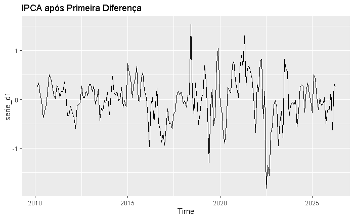

```r
autoplot(serie_d1)+
  ggtitle("IPCA após Primeira Diferença")
```

# Estatísticas Descritivas da Série Diferenciada

```r
summary(serie_d1)
```

```
     Min.   1st Qu.    Median      Mean   3rd Qu.      Max.
-1.820000 -0.240000  0.040000 -0.001026  0.260000  1.530000
```

```r
mean(serie_d1)
```

```
[1] -0.001025641
```

```r
sd(serie_d1)
```

```
[1] 0.4688217
```

# Novos Testes de Estacionariedade

## ADF

```r
adf.test(serie_d1)
```

```
    Augmented Dickey-Fuller Test

data:  serie_d1
Dickey-Fuller = -4.4083, Lag order = 5, p-value = 0.01
alternative hypothesis: stationary
```

## KPSS

```r
kpss.test(serie_d1)
```

```
    KPSS Test for Level Stationarity

data:  serie_d1
KPSS Level = 0.068946, Truncation lag parameter = 4, p-value = 0.1
```

# Phillips-Perron. A série tornou-se estacionária após uma diferença. Nesse caso: d=1 na modelagem ARIMA.

```r
pp.test(serie_d1)
```

```
    Phillips-Perron Unit Root Test

data:  serie_d1
Dickey-Fuller Z(alpha) = -96.847, Truncation lag parameter = 4, p-value = 0.01
alternative hypothesis: stationary
```